# Obtaining Posstratification-Frame for 2019 UK General Election

## Summary of the Project

- Census data: and binned age/education variables to form 32 demographic Groups
- BES random proability survey data: used it to estimate a MR model for vote choice
- Merged 2015, 2017 and 2019 BES ranom prob. data to estimate a turnout model
- Obtained code to create dataset which Clusters Constituencies by a set of variables(socio-economic,brexit vote, etc)
- Used the Clusters as predictors in the MR and Turnout models https://medium.com/analytics-vidhya/segmenting-uk-constituencies-using-unsupervised-random-forest-boruta-and-k-means-clustering-2d21f6c3b368
- Predicted vote choice of BES individual using MR model
- Predicted turnout probabilities individuals using turnout model
- Aggregated the probabilities estimates to Demographic Group level
- Merged census data with the BES data
- Estimated number of votes for each party in each constituency
- scaled the estimated votes to match the actual 2019 election results at constituency level
- Reported scaled estimated vote numbers on constituency * demographic group level

## Census Data

- Load and explore Census data.
- Clean demographic variables for BES data matching later on

```r
# AGE: renaming and filtering
# age_code: census$Age..B...14.categories..Code, age_label: census$Age..B...14.categories..Label
census <- census %>%
  rename(age_code = Age..B...14.categories..Code,
         age_label = Age..B...14.categories.) %>%
  filter(age_code >= 3 & age_code <= 14) %>%
  mutate(age_group = case_when(
    age_code %in% c(3, 4, 5, 6) ~ "Aged 20 to 39 years",
    age_code %in% c(7, 8, 9, 10) ~ "Aged 40 to 59 years",
    age_code %in% c(11) ~ "Aged 60 to 74 years",
    age_code %in% c(12, 13, 14) ~ "Aged 75 years and over"
  ))

# EDUCTION: renaming and recoding
# unique(census$Highest.level.of.qualification..8.categories.)

census <- census %>%
  rename(education_code = Highest.level.of.qualification..8.categories..Code,
         education_label = Highest.level.of.qualification..8.categories.) %>%
  mutate(education_recode = case_when(
    education_code %in% c(0) ~ 0,  # no qualifications/low qualifications like GCSE
    education_code %in% c(2, 3, 4, 5) ~ 1,  # intermediate qualifications like good GCSE or Apprenticeship
    education_code %in% c(6, 7) ~ 2,  # advanced level/higher education strong A levels or University etc.
    TRUE ~ 3  # other/not categorized
  )) %>%
  mutate(education_recode = factor(education_recode,
                                   labels = c("No/Low Qualifications",
                                              "Intermediate Qualifications",
                                              "Advanced/Higher Education",
                                              "Other/Not Categorized")))

# SEX: renaming
census <- census %>%
  rename(sex_code = Sex..2.categories..Code,  # female = 1, male = 0
         sex_label = Sex..2.categories.) %>%
  group_by(age_group, education_recode, sex_label, Westminster.Parliamentary.constituencies.Code) %>%
  summarise(total_observations = sum(Observation))
```

# Census Data Descriptives

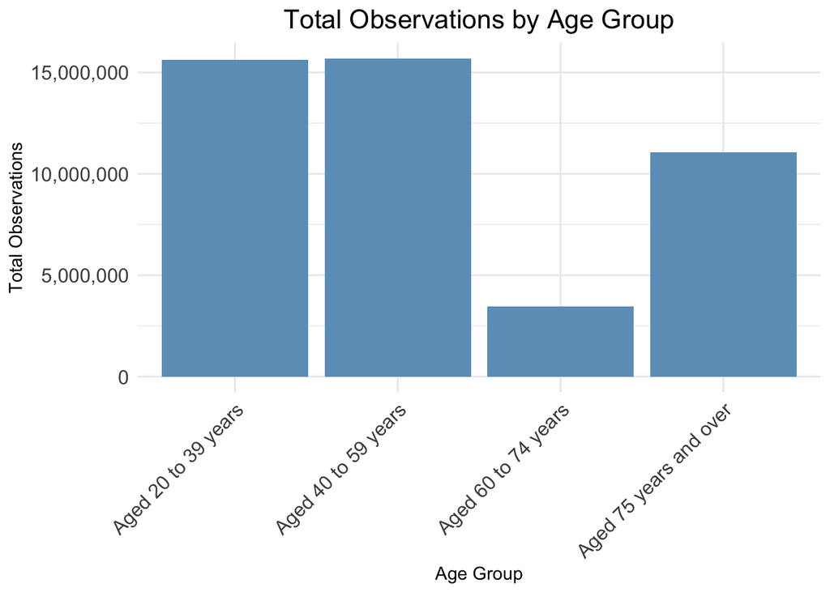

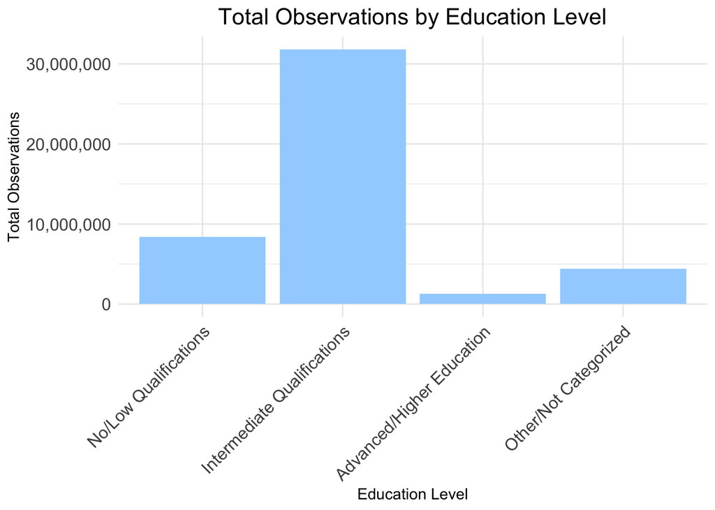

# BES data

Using unweighted raw responses to BES questions Cleaning and recoding variables to match census data

```r
cols_needed <- c("age_group", "education_recode", "sex_label", "Constit_Code",
                "turned_out", "politically_interested", "immigration_stance", "marital_status", "constituency", "Cluster_Group",
                "party_voted_for")
clean_and_recode_BES <- function(bes_data, cluster_data) {
  # Merge BES with cluster groups data
  if ("Constit_Code" %in% names(bes_data)) {
    bes_data <- merge(bes_data, cluster_data, by.x = "Constit_Code", by.y = "Constituency_Code", all.x = TRUE)
  }

  bes_data <- bes_data %>%
    select(-starts_with("w")) %>%
    mutate(party_voted_for = case_when(
      b02 == 1 ~ "Labour Party",
      b02 == 2 ~ "Conservative Party",
      b02 == 3 ~ "Liberal Democrats",
      b02 %in% c(-999, 0, -1, 11, 12, 13) ~ NA_character_,
      TRUE ~ "Other Party"
    )) %>%
    filter(!is.na(party_voted_for) & party_voted_for != "Not Applicable") %>%
    mutate(age_group = as.numeric(cut(Age, breaks = c(19, 39, 59, 74, Inf), labels = FALSE, right = FALSE)) - 1,
           age_group = case_when(
             age_group == 0 ~ "Aged 20 to 39 years",
             age_group == 1 ~ "Aged 40 to 59 years",
             age_group == 2 ~ "Aged 60 to 74 years",
             age_group == 3 ~ "Aged 75 years and over"
           ),
           education_recode = case_when(
             #
             education %in% c(0, 5,  6, 14, 12) ~ 0,
             education %in% c(1,4,10, 11, 12, 13, 17) ~ 1,
             education %in% c(2, 3, 7, 8, 9, 16, 18) ~ 2,
             TRUE ~ 3
           ),
           sex_label = case_when(
             y09 == 1 ~ "Male",
             y09 == 2 ~ "Female",
             TRUE ~ NA_character_
           ),
           politically_interested = a03,
           immigration_stance = j01,
           marital_status = y26
           ) %>%
    filter(!is.na(age_group) & !is.na(sex_label)) %>%
    mutate(age_group = as.factor(age_group),
           education_recode = as.factor(education_recode),
           sex_label = as.factor(sex_label),
           turned_out = as.factor(case_when(
             b01 == 1 ~ "1",
             b01 == 2 ~ "0",
             TRUE ~ NA_character_
           )),
           party_voted_for = as.factor(party_voted_for),
           constituency = ifelse("Constit_Name" %in% names(bes_data), as.factor(bes_data$Constit_Name), NA),
           constituency_code = ifelse("Constit_Code" %in% names(bes_data), as.factor(bes_data$Constit_Code), NA)) %>%
    filter(!is.na(turned_out)) %>%
    select(all_of(cols_needed))

  return(bes_data)
}

# Clean and recode each BES dataset
BES <- clean_and_recode_BES(BES, cluster_data)
BES_voted <- BES[BES$turned_out == 1, ]

BES_2015 <- clean_and_recode_BES(BES_2015, cluster_data)
BES_2017 <- clean_and_recode_BES(BES_2017, cluster_data)

# need to convert columns for binding BES datasets
convert_and_clean <- function(df) {
  df %>%
    mutate(across(where(is.labelled), as_factor))  # convert labelled columns to factors

}

# converting each dataset
BES_converted <- convert_and_clean(BES)
BES_2015_converted <- convert_and_clean(BES_2015)
BES_2017_converted <- convert_and_clean(BES_2017)

# combine datasets
BES_combined <- rbind(BES_2015_converted, BES_2017_converted, BES_converted)
```

# BES Descriptive Statistics

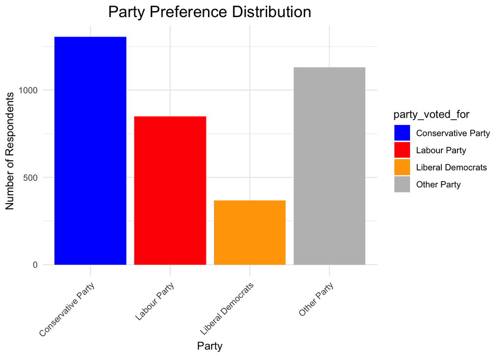

Observed Turnout by Age and Education

| age_group | No/Low Qualifications | Intermediate Qualifications | Advanced/Higher Education | Other/Not Categorized |
| --- | --- | --- | --- | --- |
| Aged 20 to 39 years | 0.52 | 0.73 | 0.78 | 0.53 |
| Aged 40 to 59 years | 0.70 | 0.85 | 0.86 | 0.73 |
| Aged 60 to 74 years | 0.81 | 0.89 | 0.90 | 0.85 |
| Aged 75 years and over | 0.82 | 0.90 | 0.96 | 0.87 |

# Comparing BES and Census distributions

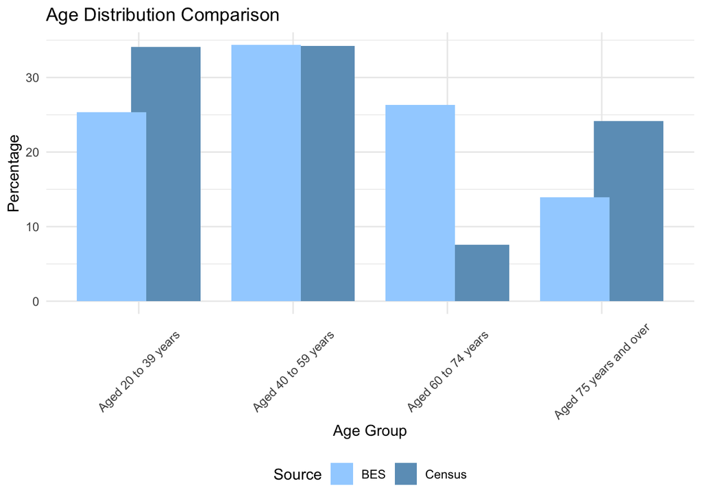

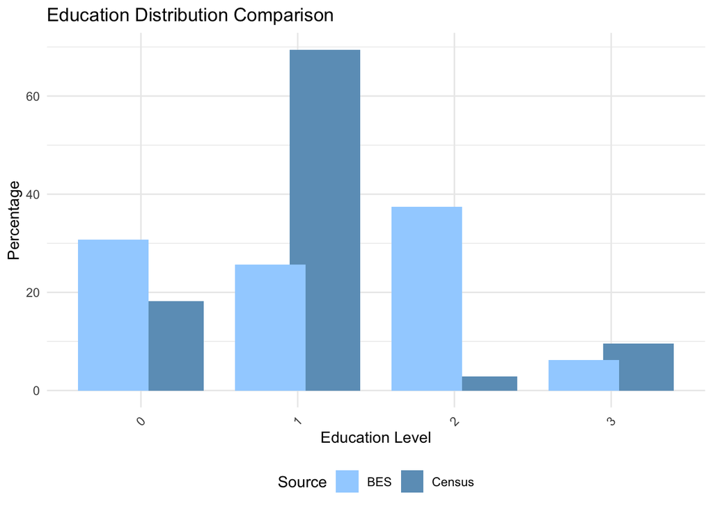

# Comparing an XGBoost model to logisitc regression for turnout prediction

```r
# 80/20 Train-Test Split
set.seed(17) # for reproducibility
training_indices <- createDataPartition(BES_combined$turned_out, p = 0.8, list = FALSE)
training_indices <- as.vector(training_indices)
training_data <- BES_combined[training_indices, ]
testing_data <- BES_combined[-training_indices, ]

# only relevant columns for XGBoost
training_data_xgb <- training_data
testing_data_xgb <- testing_data

# make sure the colums are all factor variables:
training_data_xgb <- training_data_xgb %>%
  mutate_if(is.character, as.factor)

# drop NA rows
training_data_xgb <- na.omit(training_data_xgb)
testing_data_xgb <- na.omit(testing_data_xgb)

training_data_xgb$turned_out <- as.numeric(as.character(training_data_xgb$turned_out))
testing_data_xgb$turned_out <- as.numeric(as.character(testing_data_xgb$turned_out))

training_data_xgb$turned_out[1:10]
```

```
##  [1] 0 1 1 0 1 1 0 1 1 0
```

```r
#  matrices for XGBoost
dtrain <- xgb.DMatrix(data = data.matrix(training_data_xgb[, -which(names(training_data_xgb) == "turned_out")]),
                      label = training_data_xgb$turned_out)
dtest <- xgb.DMatrix(data = data.matrix(testing_data_xgb[, -which(names(testing_data_xgb) == "turned_out")]),
                     label = testing_data_xgb$turned_out)

# turnout model : logistic regressoin
turnout_model <- glmer(formula = turned_out ~  politically_interested + age_group + education_recode +
                       sex_label + (1 | Cluster_Group), # add constituency group
                       family = binomial(link = "logit"),
                       data = training_data,
                       # dont print out iteratinos
                       control = glmerControl( optCtrl = list(maxfun = 2e5)))


# XGBoost Model
params <- list(booster = "gbtree", objective = "binary:logistic", eta = 0.3, max_depth = 6)
xgb_model <- xgb.train(params = params, data = dtrain, nrounds = 100)

# predict and calculate accuracy
logistic_preds <- predict(turnout_model, newdata = testing_data, type = "response")
binary_logistic_preds <- as.numeric(logistic_preds > 0.5)

# Ensure testing_data$turned_out is a numeric vector
testing_data$turned_out <- as.numeric(as.character(testing_data$turned_out))

# Calculate accuracy
logistic_accuracy <- mean(binary_logistic_preds == testing_data$turned_out)

# XGBoost predictions
xgb_preds <- predict(xgb_model, dtest)
xgb_preds <- as.vector(xgb_preds)
xgb_accuracy <- mean((xgb_preds > 0.5) == testing_data_xgb$turned_out)

# compare accuracies
accuracy_comparison <- data.frame(Model = c("Logistic Regression", "XGBoost"),
                                  Accuracy = c(logistic_accuracy, xgb_accuracy))

print(accuracy_comparison)
```

```
##                 Model  Accuracy
## 1 Logistic Regression 0.8148361
## 2             XGBoost 0.8936170
```

# Fitting Vote and Turnout Models

```r
# multinomial and brms models for party voted for
# party_model_old <- multinom(party_voted_for ~  age_group + education_recode +
                          #sex_label  + politically_interested + immigration_stance +
                          #as.factor(marital_status) + age_group:sex_label:education_recode,
                          #data = BES_voted)

# look at the default priors
# get_prior(formula = as.factor(party_voted_for) ~ age_group + education_recode + sex_label +
          #politically_interested + immigration_stance + as.factor(marital_status) +
          #(1 | (Cluster_Group)),
          #family = categorical(link = "logit"),
          #data = BES_voted)

party_model <- brm(
    formula = as.factor(party_voted_for) ~ age_group + education_recode + sex_label +
              politically_interested + immigration_stance + (1 | Cluster_Group), #  + as.factor(marital_status)
    family = categorical(link = "logit"),
    data = BES_voted,
    cores = 6,
    chains = 4,
    iter = 2000)

# posteiror summary(party_model)
party_model_summary <- summary(party_model)
```

# Predicting on BES data and aggregating at demographic group level

```r
######MULTINOMIAL CASE:
# predicted_probs <- party_predictions_old
# party_model <- party_model_old
##################

# XGBoost predictions for turnout probabilities
# Remove the response variable 'turned_out'
BES_for_xgb <- BES[, -which(names(BES) == "turned_out")]
dmatrix_for_prediction <- xgb.DMatrix(data = data.matrix(BES_for_xgb))
xgb_probs <- predict(xgb_model, dmatrix_for_prediction)
BES$predicted_turnout <- xgb_probs

# vote predictions
predicted_probs <- predict(party_model, BES)

# preparing predicted probabilities
predicted_probs_df <- as.data.frame(predicted_probs)
colnames(predicted_probs_df) <- c("Con", "Lab", "Lib", "Other")

# cleaning BES data and combining with predicted probabilities
BES_cleaned <- BES %>%
  select(age_group, education_recode, sex_label,
        turned_out, predicted_turnout, party_voted_for,
        Constit_Code, politically_interested, immigration_stance, marital_status, constituency, Cluster_Group) %>%
  cbind(predicted_probs_df)

# aggregating BES Predictions by demographic variables
BES_aggregated <- BES_cleaned %>%
  group_by(age_group, education_recode, sex_label) %>%
  summarise(
    avg_predicted_turnout_prob = mean(predicted_turnout, na.rm = TRUE),
    avg_con = mean(Con, na.rm = TRUE),
    avg_lab = mean(Lab, na.rm = TRUE),
    avg_lib = mean(Lib, na.rm = TRUE),
    avg_other = mean(Other, na.rm = TRUE)
  )
```

# Visualizing Predictions

```
## Top 3 Highest Turnout Demographic Groups:
```

```
## # A tibble: 3 × 3
## # Groups:   age_group [2]
##   age_group              education_recode            avg_turnout_rate
##   <fct>                  <fct>                                  <dbl>
## 1 Aged 75 years and over Advanced/Higher Education              0.940
## 2 Aged 75 years and over Intermediate Qualifications            0.939
## 3 Aged 60 to 74 years    Advanced/Higher Education              0.927
```

```
##
## Lowest 3 Turnout Demographic Groups:
```

```
## # A tibble: 3 × 3
## # Groups:   age_group [2]
##   age_group           education_recode      avg_turnout_rate
##   <fct>               <fct>                            <dbl>
## 1 Aged 40 to 59 years No/Low Qualifications            0.788
## 2 Aged 20 to 39 years Other/Not Categorized            0.758
## 3 Aged 20 to 39 years No/Low Qualifications            0.609
```

Summary Table of Predictions

| age_group | education_recode | avg_predicted_turnout_prob | avg_con | avg_lab | avg_lib | avg_other |
| --- | --- | --- | --- | --- | --- | --- |
| Aged 20 to 39 years | No/Low Qualifications | 0.6085980 | 0.3217517 | 0.4405054 | 0.0642621 | 0.1734807 |
| Aged 20 to 39 years | Intermediate Qualifications | 0.8018807 | 0.2426153 | 0.4655606 | 0.1265490 | 0.1652752 |
| Aged 20 to 39 years | Advanced/Higher Education | 0.7929040 | 0.2504184 | 0.4927222 | 0.1160586 | 0.1408007 |
| Aged 20 to 39 years | Other/Not Categorized | 0.7581715 | 0.2943875 | 0.3819187 | 0.1330625 | 0.1906312 |
| Aged 40 to 59 years | No/Low Qualifications | 0.7878683 | 0.4856354 | 0.2690163 | 0.0752905 | 0.1700578 |
| Aged 40 to 59 years | Intermediate Qualifications | 0.8753460 | 0.3987077 | 0.2795765 | 0.1495777 | 0.1721382 |
| Aged 40 to 59 years | Advanced/Higher Education | 0.8788637 | 0.4074935 | 0.2986582 | 0.1437073 | 0.1501410 |
| Aged 40 to 59 years | Other/Not Categorized | 0.8425382 | 0.4460312 | 0.2119073 | 0.1540673 | 0.1879942 |
| Aged 60 to 74 years | No/Low Qualifications | 0.8176677 | 0.5843029 | 0.1899662 | 0.0791034 | 0.1466274 |
| Aged 60 to 74 years | Intermediate Qualifications | 0.8900658 | 0.4850499 | 0.2116925 | 0.1487596 | 0.1544979 |
| Aged 60 to 74 years | Advanced/Higher Education | 0.9266770 | 0.4977685 | 0.2276917 | 0.1446267 | 0.1299131 |
| Aged 60 to 74 years | Other/Not Categorized | 0.9019862 | 0.5358225 | 0.1658376 | 0.1195910 | 0.1787490 |
| Aged 75 years and over | No/Low Qualifications | 0.8414133 | 0.6380609 | 0.1774456 | 0.0849295 | 0.0995640 |
| Aged 75 years and over | Intermediate Qualifications | 0.9386944 | 0.5283739 | 0.2041918 | 0.1669969 | 0.1004374 |
| Aged 75 years and over | Advanced/Higher Education | 0.9404634 | 0.5438818 | 0.2136346 | 0.1460981 | 0.0963855 |
| Aged 75 years and over | Other/Not Categorized | 0.9261716 | 0.5769214 | 0.1470303 | 0.1523320 | 0.1237163 |

# Merging Census and BES data

```r
# aligning education_recode levels in BES_aggregated to match census
levels(BES_aggregated$education_recode) <- c("No/Low Qualifications",
                                             "Intermediate Qualifications",
                                             "Advanced/Higher Education",
                                             "Other/Not Categorized")

#  sex_label asfactor with consistent levels (if necessary)
if(!is.null(levels(census$sex_label)) && !is.null(levels(BES_aggregated$sex_label))) {
  levels(BES_aggregated$sex_label) <- levels(census$sex_label)
}

#
poststrat_data <- census %>%
  left_join(BES_aggregated, by = c("age_group", "education_recode", "sex_label"))

# estimating votes on post-stratification data
poststrat_data <- poststrat_data %>%
  mutate(
    est_votes_con = total_observations * avg_predicted_turnout_prob * avg_con,
    est_votes_lab = total_observations * avg_predicted_turnout_prob * avg_lab,
    est_votes_lib = total_observations * avg_predicted_turnout_prob * avg_lib,
    est_votes_other = total_observations * avg_predicted_turnout_prob * avg_other
  )
```

# Poststratification

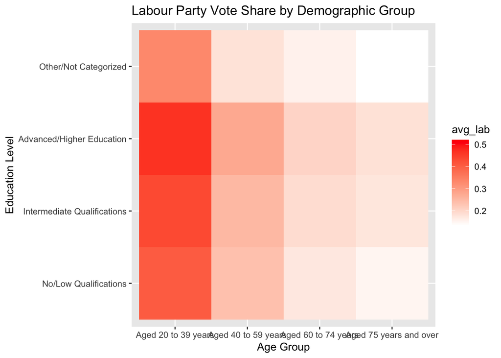

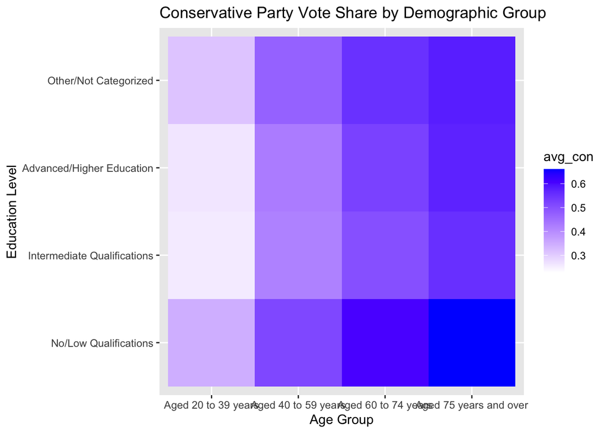

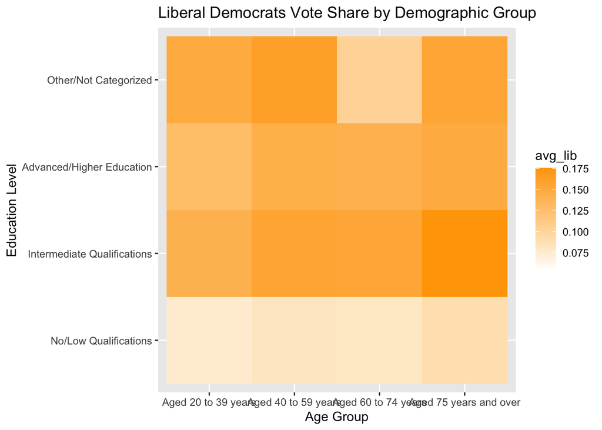

```r
# filter actual results to only include constituencies in the poststratification frame
actual_results <- actual_results %>%
  filter(Country == 1 | Country == 3) %>% # remove scotland
  select(ONSConstID, Winner19, ConVote19, LabVote19, LDVote19, TotalVote19) %>%
  mutate(OtherVote19 = TotalVote19 - (ConVote19 + LabVote19 + LDVote19))

# aggregate estimated votes by constituency
constituency_estimates <- poststrat_data %>%
  group_by(Westminster.Parliamentary.constituencies.Code) %>%
  summarise(
    est_votes_con_total = sum(est_votes_con),
    est_votes_lab_total = sum(est_votes_lab),
    est_votes_lib_total = sum(est_votes_lib),
    est_votes_other_total = sum(est_votes_other)
  )

# join with actual results
comparison <- constituency_estimates %>%
  left_join(actual_results, by = c("Westminster.Parliamentary.constituencies.Code" = "ONSConstID"))

# calculate scaling factors and apply them
comparison <- comparison %>%
  mutate(
    scale_factor_con = ConVote19 / est_votes_con_total,
    scale_factor_lab = LabVote19 / est_votes_lab_total,
    scale_factor_lib = LDVote19 / est_votes_lib_total,
    scale_factor_other = OtherVote19 / est_votes_other_total
  ) %>%
  mutate(
    scaled_est_votes_con = est_votes_con_total * scale_factor_con,
    scaled_est_votes_lab = est_votes_lab_total * scale_factor_lab,
    scaled_est_votes_lib = est_votes_lib_total * scale_factor_lib,
    scaled_est_votes_other = est_votes_other_total * scale_factor_other
  )

# apply scaling factors to poststrat data
final_poststrat_data <- poststrat_data %>%
  left_join(comparison %>%
            select(Westminster.Parliamentary.constituencies.Code,
                   scale_factor_con,
                   scale_factor_lab,
                   scale_factor_lib,
                   scale_factor_other),
            by = "Westminster.Parliamentary.constituencies.Code") %>%
  mutate(
    scaled_est_votes_con = est_votes_con * scale_factor_con,
    scaled_est_votes_lab = est_votes_lab * scale_factor_lab,
    scaled_est_votes_lib = est_votes_lib * scale_factor_lib,
    scaled_est_votes_other = est_votes_other * scale_factor_other
  )
# sort by constituency
final_poststrat_data <- final_poststrat_data[order(final_poststrat_data$Westminster.Parliamentary.constituencies.Code), ]
View(final_poststrat_data)

# round the vote counts to the nearest integer (scaled and non scaled!)
final_poststrat_data <- final_poststrat_data %>%
  mutate(
    est_votes_con = round(est_votes_con),
    est_votes_lab = round(est_votes_lab),
    est_votes_lib = round(est_votes_lib),
    est_votes_other = round(est_votes_other),
    scaled_est_votes_con = round(scaled_est_votes_con),
    scaled_est_votes_lab = round(scaled_est_votes_lab),
    scaled_est_votes_lib = round(scaled_est_votes_lib),
    scaled_est_votes_other = round(scaled_est_votes_other)
  )

# drop the est columns
final_poststrat_data <- final_poststrat_data %>%
  select(-starts_with("est"))

# save final poststratification frame to a csv file
write.csv(final_poststrat_data, file = "final_poststrat_data.csv")

# also save a 100 row long snippet of the final poststratification frame
write.csv(final_poststrat_data[1:100, ], file = "final_poststrat_data_snippet.csv")
```

# Top/Bottom demographic groups for each party

```
##
## Top and Bottom Demographic Groups for Each Party:
```

Top and Bottom Demographic Groups for Each Party

| age_group | education_recode | sex_label | avg_lab | avg_con | avg_lib | Party | Group |
| --- | --- | --- | --- | --- | --- | --- | --- |
| Aged 20 to 39 years | Advanced/Higher Education | Female | 0.5201293 | 0.2366331 | 0.1049515 | Labour | Highest |
| Aged 75 years and over | Other/Not Categorized | Male | 0.1332700 | 0.5796800 | 0.1551000 | Labour | lowest |
| Aged 75 years and over | No/Low Qualifications | Male | 0.1501450 | 0.6607400 | 0.0904075 | Conservative | Highest |
| Aged 20 to 39 years | Intermediate Qualifications | Female | 0.4978765 | 0.2275756 | 0.1122747 | Conservative | lowest |
| Aged 75 years and over | Intermediate Qualifications | Male | 0.1743138 | 0.5536489 | 0.1756915 | Liberal Democrats | Highest |
| Aged 20 to 39 years | No/Low Qualifications | Female | 0.4771932 | 0.2974182 | 0.0531977 | Liberal Democrats | lowest |

# Votes per Party at the NAtional Level

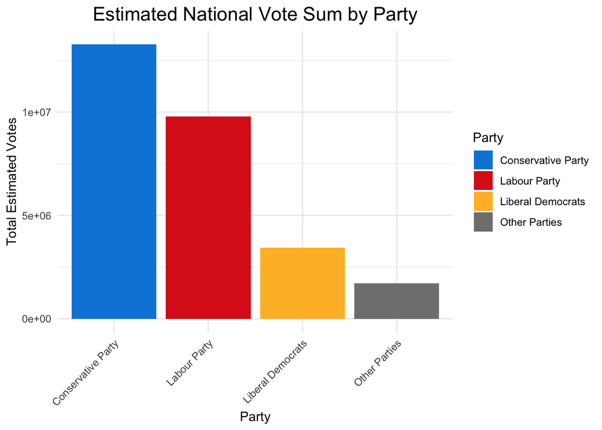

## Party model summary

```
##  Family: categorical
##   Links: muLabourParty = logit; muLiberalDemocrats = logit; muOtherParty = logit
## Formula: as.factor(party_voted_for) ~ age_group + education_recode + sex_label + politically_interested + immigration_stance + (1 | Cluster_Group)
##    Data: BES_voted (Number of observations: 2936)
##   Draws: 4 chains, each with iter = 2000; warmup = 1000; thin = 1;
##          total post-warmup draws = 4000
##
## Group-Level Effects:
## ~Cluster_Group (Number of levels: 6)
##                                  Estimate Est.Error l-95% CI u-95% CI Rhat
## sd(muLabourParty_Intercept)          0.65      0.33     0.29     1.43 1.00
## sd(muLiberalDemocrats_Intercept)     0.73      0.38     0.29     1.68 1.00
## sd(muOtherParty_Intercept)           0.46      0.26     0.14     1.13 1.00
##                                  Bulk_ESS Tail_ESS
## sd(muLabourParty_Intercept)          1138     1493
## sd(muLiberalDemocrats_Intercept)     1406     1861
## sd(muOtherParty_Intercept)           1334     1817
##
## Population-Level Effects:
##                                                Estimate Est.Error l-95% CI
## muLabourParty_Intercept                            0.54      0.32    -0.09
## muLiberalDemocrats_Intercept                      -3.78      0.48    -4.72
## muOtherParty_Intercept                            -1.43      0.33    -2.06
## muLabourParty_age_groupAged40to59years            -0.93      0.13    -1.18
## muLabourParty_age_groupAged60to74years            -1.36      0.14    -1.63
## muLabourParty_age_groupAged75yearsandover         -1.51      0.17    -1.83
## muLabourParty_education_recode1                    0.30      0.13     0.05
## muLabourParty_education_recode2                    0.34      0.12     0.11
## muLabourParty_education_recode3                   -0.12      0.23    -0.59
## muLabourParty_sex_labelMale                       -0.31      0.10    -0.50
## muLabourParty_politically_interested               0.03      0.02    -0.00
## muLabourParty_immigration_stance                  -0.00      0.00    -0.01
## muLiberalDemocrats_age_groupAged40to59years       -0.25      0.17    -0.59
## muLiberalDemocrats_age_groupAged60to74years       -0.39      0.18    -0.75
## muLiberalDemocrats_age_groupAged75yearsandover    -0.46      0.21    -0.87
## muLiberalDemocrats_education_recode1               0.74      0.18     0.39
## muLiberalDemocrats_education_recode2               0.64      0.17     0.32
## muLiberalDemocrats_education_recode3               0.70      0.27     0.16
## muLiberalDemocrats_sex_labelMale                  -0.09      0.12    -0.33
## muLiberalDemocrats_politically_interested          0.24      0.08     0.09
```

[output cut: 30 more lines]

```
## muLiberalDemocrats_politically_interested          0.40 1.00     3826     3238
## muLiberalDemocrats_immigration_stance              0.42 1.00     4888     2944
## muOtherParty_age_groupAged40to59years             -0.08 1.00     2634     2964
## muOtherParty_age_groupAged60to74years             -0.29 1.00     2849     3025
## muOtherParty_age_groupAged75yearsandover          -0.74 1.00     3092     2996
## muOtherParty_education_recode1                     0.59 1.00     3025     2890
## muOtherParty_education_recode2                     0.43 1.00     3426     3360
## muOtherParty_education_recode3                     0.65 1.00     3707     3451
## muOtherParty_sex_labelMale                         0.20 1.00     2911     1736
## muOtherParty_politically_interested                0.46 1.00     4226     3221
## muOtherParty_immigration_stance                    0.00 1.00     4065     2156
##
## Draws were sampled using sampling(NUTS). For each parameter, Bulk_ESS
## and Tail_ESS are effective sample size measures, and Rhat is the potential
## scale reduction factor on split chains (at convergence, Rhat = 1).
```